# Влияние витамина C на рост зубов морских свинок

В эксперименте изучалось влияние витамина C на рост одонтобластов морских свинок.

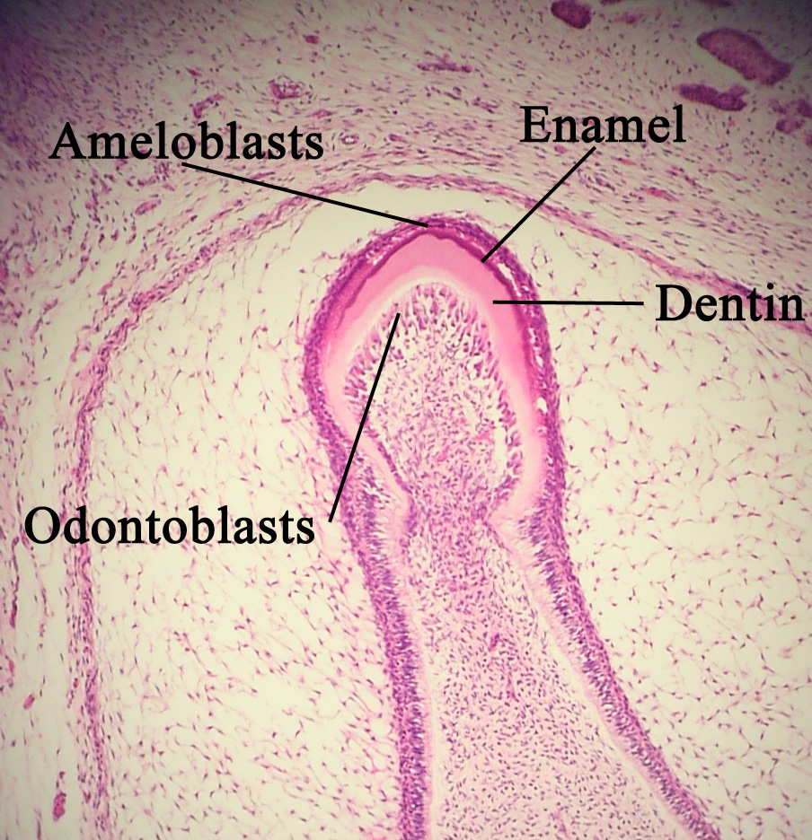

Рассматривалось три дозы витамина (0.5, 1 и 2 мг) и два способа его приёма (апельсиновый сок и аскорбиновая кислота). В каждой из 6 групп по уровням двух факторов были произведены измерения для 10 морских свинок.

```r
ToothGrowth$dose <- factor(ToothGrowth$dose)
summary(ToothGrowth)
```

```
##       len        supp     dose
##  Min.   : 4.20   OJ:30   0.5:20
##  1st Qu.:13.07   VC:30   1  :20
##  Median :19.25           2  :20
##  Mean   :18.81
##  3rd Qu.:25.27
##  Max.   :33.90
```

```r
table(ToothGrowth$dose)
```

```
##
## 0.5   1   2
##  20  20  20
```

```r
table(ToothGrowth$supp, ToothGrowth$dose)
```

```
##
##      0.5  1  2
##   OJ  10 10 10
##   VC  10 10 10
```

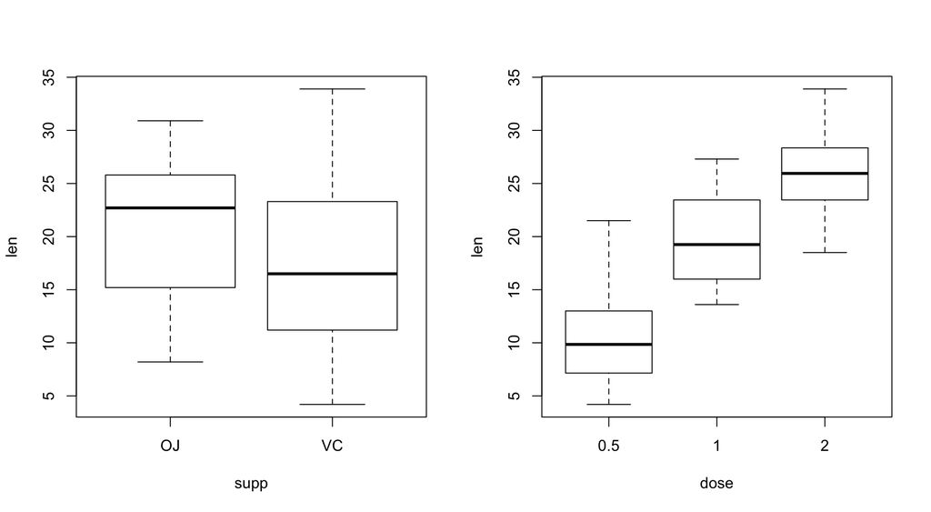

1. Применим нормальный двухфакторный дисперсионный анализ без учета и с учтом межфакторного взаимодействия. Для функции `aov` характер взаимодействия учитывается с помощью первого аргумента - формулы. Для ANOVA без учета взаимодейтсвия `len ~ supp+dose`. Для ANOVA c учетом `len ~ supp*dose`. Проведите оба анализа и проанализируйте вывод функции `model.tables` для каждого случая. Кроме этого воспользуйтесь функцией `EtaSq` из пакета `DescTools` для анализа того, какое количество дисперсии объясняется каждым элементом модели (фактором / взаимодействия).

```r
summary(aov(len ~ supp+dose, data=ToothGrowth))
```

```
##             Df Sum Sq Mean Sq F value   Pr(>F)
## supp         1  205.4   205.4   14.02 0.000429 ***
## dose         2 2426.4  1213.2   82.81  < 2e-16 ***
## Residuals   56  820.4    14.7
## ---
## Signif. codes:  0 '***' 0.001 '**' 0.01 '*' 0.05 '.' 0.1 ' ' 1
```

```r
anova0 <- aov(len ~ supp*dose, data=ToothGrowth)
summary(anova0)
```

```
##             Df Sum Sq Mean Sq F value   Pr(>F)
## supp         1  205.4   205.4  15.572 0.000231 ***
## dose         2 2426.4  1213.2  92.000  < 2e-16 ***
## supp:dose    2  108.3    54.2   4.107 0.021860 *
## Residuals   54  712.1    13.2
## ---
## Signif. codes:  0 '***' 0.001 '**' 0.01 '*' 0.05 '.' 0.1 ' ' 1
```

```r
par(mfrow=c(2,2))
model.tables(anova0, "means")
```

```
## Tables of means
## Grand mean
##
## 18.81333
##
##  supp
## supp
##     OJ     VC
## 20.663 16.963
##
##  dose
## dose
##    0.5      1      2
## 10.605 19.735 26.100
##
##  supp:dose
##     dose
## supp 0.5   1     2
##   OJ 13.23 22.70 26.06
##   VC  7.98 16.77 26.14
```

```r
library(DescTools)
EtaSq(anova0)
```

```
##               eta.sq eta.sq.part
## supp      0.05948365   0.2238254
## dose      0.70286419   0.7731092
## supp:dose 0.03137672   0.1320279
```

2. Межфакторное взаимодействие можно неплохо визуализировать для более-менее простых случаев c помощью команды `interaction.plot`. Получите графики зависимостей, если по оси x откладывать `supp` и если по оси x откладывать `dose`. Проинтепретируйте полученные зависимости.

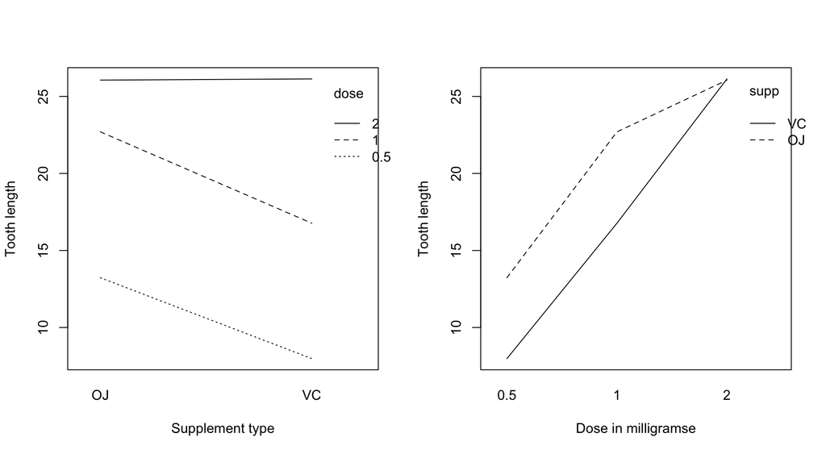

```r
par(mfrow=c(1,2))
with(ToothGrowth,  interaction.plot(supp, dose, len, xlab="Supplement type",  ylab="Tooth length"))
with(ToothGrowth,  interaction.plot(dose, supp, len, xlab="Dose in milligramse",  ylab="Tooth length"))
```

3. Взаимодействие значимо, поэтому разделим выборку по способу приёма витамина (колонка `supp`).

```r
OJ <- subset(ToothGrowth, supp=="OJ")[,-2]
VC <- subset(ToothGrowth, supp=="VC")[,-2]
```

Проведите дисперсионный анализ внутри каждой из групп:

- Для морских свинок, принимающих аскорбиновую кислоту
- Для морских свинок, принимающих апельсиновый сок

Вам нужно * Построить гарфик зависимостей `len ~ dose`

- Построить `aov` модель `len ~ dose`. Посмотреть на вывод `summary` и `model.tables`
- Проведите следующие тесты: `kruskal.test`, `TukeyHSD`, `jonckheere.test`
- Сделать выводы по для каждой из груп свинок

Для морских свинок, принимающих аскорбиновую кислоту:

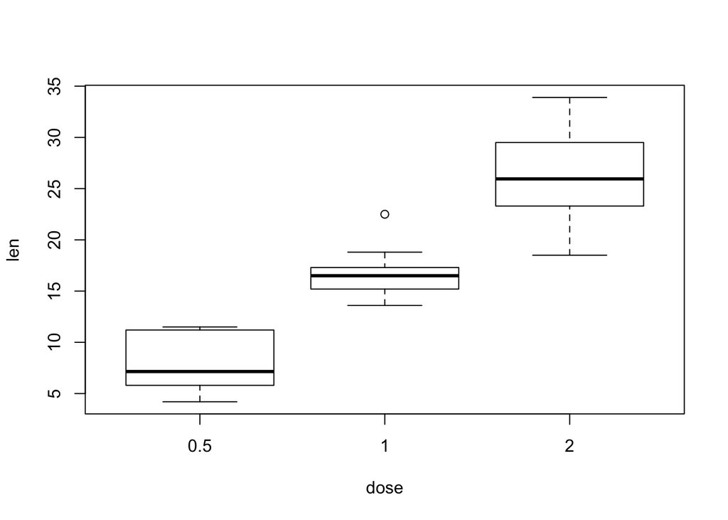

```r
plot(len ~ dose, data=VC)
```

```r
anova1 <- aov(len ~ dose, data=VC)
summary(anova1)
```

```
##             Df Sum Sq Mean Sq F value   Pr(>F)
## dose         2   1650   824.7   67.07 3.36e-11 ***
## Residuals   27    332    12.3
## ---
## Signif. codes:  0 '***' 0.001 '**' 0.01 '*' 0.05 '.' 0.1 ' ' 1
```

```r
par(mfrow=c(2,2))
model.tables(anova1, "means")
```

```
## Tables of means
## Grand mean
##
## 16.96333
##
##  dose
## dose
##   0.5     1     2
##  7.98 16.77 26.14
```

```r
EtaSq(anova1)
```

```
##         eta.sq eta.sq.part
## dose 0.8324488   0.8324488
```

```r
kruskal.test(VC$len, VC$dose)
```

```
##
##  Kruskal-Wallis rank sum test
##
## data:  VC$len and VC$dose
## Kruskal-Wallis chi-squared = 25.072, df = 2, p-value = 3.594e-06
```

```r
library(clinfun)
```

```r
jonckheere.test(VC$len, as.numeric(VC$dose))
```

```
##
##  Jonckheere-Terpstra test
##
## data:
## JT = 297, p-value = 2.278e-08
## alternative hypothesis: two.sided
```

```r
TukeyHSD(anova1)
```

```
##   Tukey multiple comparisons of means
##     95% family-wise confidence level
##
## Fit: aov(formula = len ~ dose, data = VC)
##
## $dose
##        diff       lwr      upr    p adj
## 1-0.5  8.79  4.901765 12.67824 1.75e-05
## 2-0.5 18.16 14.271765 22.04824 0.00e+00
## 2-1    9.37  5.481765 13.25824 6.60e-06
```

Для морских свинок, принимающих апельсиновый сок:

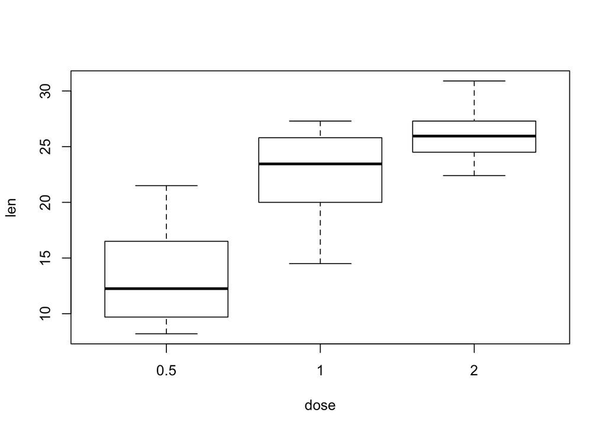

```r
plot(len ~ dose, data=OJ)
```

```r
anova2 <- aov(len ~ dose, data=OJ)
summary(anova2)
```

```
##             Df Sum Sq Mean Sq F value   Pr(>F)
## dose         2  885.3   442.6   31.44 8.89e-08 ***
## Residuals   27  380.1    14.1
## ---
## Signif. codes:  0 '***' 0.001 '**' 0.01 '*' 0.05 '.' 0.1 ' ' 1
```

```r
par(mfrow=c(2,2))
model.tables(anova2, "means")
```

```
## Tables of means
## Grand mean
##
## 20.66333
##
##  dose
## dose
##   0.5     1     2
## 13.23 22.70 26.06
```

```r
EtaSq(anova2)
```

```
##         eta.sq eta.sq.part
## dose 0.6996095   0.6996095
```

```r
kruskal.test(OJ$len, OJ$dose)
```

```
##
##  Kruskal-Wallis rank sum test
##
## data:  OJ$len and OJ$dose
## Kruskal-Wallis chi-squared = 18.506, df = 2, p-value = 9.584e-05
```

```r
jonckheere.test(OJ$len, as.numeric(OJ$dose))
```

```
##
##  Jonckheere-Terpstra test
##
## data:
## JT = 266, p-value = 1.03e-05
## alternative hypothesis: two.sided
```

```r
TukeyHSD(anova2)
```

```
##   Tukey multiple comparisons of means
##     95% family-wise confidence level
##
## Fit: aov(formula = len ~ dose, data = OJ)
##
## $dose
##        diff        lwr       upr     p adj
## 1-0.5  9.47  5.3096046 13.630395 0.0000158
## 2-0.5 12.83  8.6696046 16.990395 0.0000001
## 2-1    3.36 -0.8003954  7.520395 0.1309258
```

Crampton E. W. (1947) **The growth of the odontoblast of the incisor teeth as a criterion of vitamin C intake of the guinea pig.** The Journal of Nutrition 33(5): 491–504.